# native_late_adipoDE

Sarah Hazell Pickering

2/9/2022

## Summary

The D7 floating adipocytes are quite different between replicates, but still very distinct from bulk adipocyte samples (see PCA plot). I was a bit concerned about the normalisation of some of the donor7 replicates (samples 418 and 419 which were both P8 I think). But in the end I settled for a stringent pvalue threshold of 0.01 and the GO terms make alot of sense. Floating adipocytes are enriched for mitochondrial metabolism genes or adipogenesis hallmarks, whilst bulk samples are enriched for genes related to the extracellular matrix and/or blood vessel morphogenesis. outputs are rpkm tables (as always) and native_bulk.v.float.tab, which shows pvalues and logFCs for DE between bulk and floating adipocytes (D7 only and D13 only stats are given in the right most columns as well).

```r
library(limma)
library(biomaRt)
library(org.Hs.eg.db)
```

```r
library(ggplot2)
library(RUVSeq)
library(clusterProfiler)
limma_dir = "/projects/imb-pkbphil/sp/rnaseq/late_adipo_feb22/output/03limma"
```

### Load read counts

```r
fc = read.delim(file.path(limma_dir, "../02featureCounts/late_adipo_feb22.counts"),
                header=T, stringsAsFactors = F, skip = 1)
colnames(fc) = gsub("output.01hisat.","", gsub(".sorted.bam","",colnames(fc)))
head(fc)
```

```
##            Geneid                   Chr
## 1 ENSG00000223972     1;1;1;1;1;1;1;1;1
## 2 ENSG00000227232 1;1;1;1;1;1;1;1;1;1;1
## 3 ENSG00000278267                     1
## 4 ENSG00000243485             1;1;1;1;1
## 5 ENSG00000284332                     1
## 6 ENSG00000237613             1;1;1;1;1
##                                                               Start
## 1             11869;12010;12179;12613;12613;12975;13221;13221;13453
## 2 14404;15005;15796;16607;16858;17233;17606;17915;18268;24738;29534
## 3                                                             17369
## 4                                     29554;30267;30564;30976;30976
## 5                                                             30366
## 6                                     34554;35245;35277;35721;35721
##                                                                 End
```

[output cut: 41 more lines]

### Load sample information

```r
sample_info = read.delim(file.path(limma_dir, "late_adipo_sample_info.txt"),
                header=T)
sample_info$sample_id = gsub("-",".", sample_info$sample_id)
sample_info$bio.condition = gsub(" ",".", sample_info$bio.condition)
sample_info
```

```
##    time  rep researcher cell_type construct donor separation bio.condition
## 1   D15 Rep1         LP      APEX      LMNA  D07G       bulk          LMNA
## 2   D15 Rep2         LP      APEX      LMNA  D07G       bulk          LMNA
## 3   D15 Rep3         LP      APEX      LMNA  D07G       bulk          LMNA
## 4   D15 Rep1         LP      APEX     R482W  D07G       bulk         R482W
## 5   D15 Rep2         LP      APEX     R482W  D07G       bulk         R482W
## 6   D15 Rep3         LP      APEX     R482W  D07G       bulk         R482W
## 7   D21 Rep1         LP      APEX      LMNA  D07G       bulk          LMNA
## 8   D21 Rep2         LP      APEX      LMNA  D07G       bulk          LMNA
## 9   D21 Rep3         LP      APEX      LMNA  D07G       bulk          LMNA
## 10  D21 Rep1         LP      APEX     R482W  D07G       bulk         R482W
## 11  D21 Rep2         LP      APEX     R482W  D07G       bulk         R482W
## 12  D21 Rep3         LP      APEX     R482W  D07G       bulk         R482W
## 13  D15   P6               native    native  D07G   floating D07G.floating
## 14  D15 P8_1               native    native  D07G   floating D07G.floating
```

[output cut: 35 more lines]

###Combine into DGE object

```r
ob = DGEList(counts = data.matrix(fc[7:ncol(fc)]),
             samples = sample_info,
             group = sample_info$bio.condition,
             genes = fc[c(1,6)])
rownames(ob$counts) = ob$genes$Geneid
```

### Filter out apex samples

```r
ob$counts = ob$counts[,ob$samples$cell_type =="native"]
ob$samples = ob$samples[ob$samples$cell_type =="native",]
head(ob)
```

```
## An object of class "DGEList"
## $counts
##                 13.21417_S53 14.21418_S2 15.21419_S9 16.21420_S16 17.21421_S24
## ENSG00000223972         2.98        0.60        4.02         6.99         8.54
## ENSG00000227232        71.95       63.77      116.12        83.60        95.42
## ENSG00000278267         5.00        3.00        1.00         1.00         1.00
## ENSG00000243485         0.00        1.00        0.00         0.45         0.50
## ENSG00000284332         0.00        0.00        0.00         0.00         0.00
## ENSG00000237613         5.38       11.66       18.16         0.00         0.00
##                 18.21422_S32 19.21423_S40 20.21424_S47 21.21425_S54 22.21426_S3
## ENSG00000223972         5.99         2.88         1.37         1.70        4.13
## ENSG00000227232        60.59        86.75       169.35       144.65       83.21
## ENSG00000278267         1.00         6.75         6.90         5.25        8.84
## ENSG00000243485         0.00         0.79         1.75         0.70        0.00
## ENSG00000284332         0.00         0.00         0.00         0.00        0.00
## ENSG00000237613         0.00        11.62        31.77        17.51        0.00
##                 23.21427_S10 24.21428_S17
## ENSG00000223972         8.44         5.39
## ENSG00000227232       112.73       265.86
## ENSG00000278267         3.50        11.40
## ENSG00000243485         0.50         0.53
## ENSG00000284332         0.00         0.00
## ENSG00000237613         0.00         0.50
##
## $samples
##                      group lib.size norm.factors time  rep researcher cell_type
## 13.21417_S53 D07G.floating 39520835            1  D15   P6               native
## 14.21418_S2  D07G.floating 43198916            1  D15 P8_1               native
## 15.21419_S9  D07G.floating 53192791            1  D15 P8_2               native
## 16.21420_S16 D13A.floating 58757001            1  D15 P6_1         NB    native
## 17.21421_S24 D13A.floating 64220795            1  D15 P6_2         EP    native
##              construct donor separation bio.condition    sample_id
## 13.21417_S53    native  D07G   floating D07G.floating 13.21417_S53
## 14.21418_S2     native  D07G   floating D07G.floating  14.21418_S2
## 15.21419_S9     native  D07G   floating D07G.floating  15.21419_S9
## 16.21420_S16    native  D13A   floating D13A.floating 16.21420_S16
## 17.21421_S24    native  D13A   floating D13A.floating 17.21421_S24
## 7 more rows ...
##
## $genes
##            Geneid Length
## 1 ENSG00000223972   1735
## 2 ENSG00000227232   1351
## 3 ENSG00000278267     68
## 4 ENSG00000243485   1021
## 5 ENSG00000284332    138
## 6 ENSG00000237613   1219
```

## PCA

Bulk and floating transcriptomes are more different for donor7 than donor13. This first dimension does separate bulk and floating (though better for donor7) and the second dimension seems to separate donors. Bulk adipocytes have similarities between donors, but the floating adipocytes seem quite different from one another, even with donor7 there’s a lot of variability.

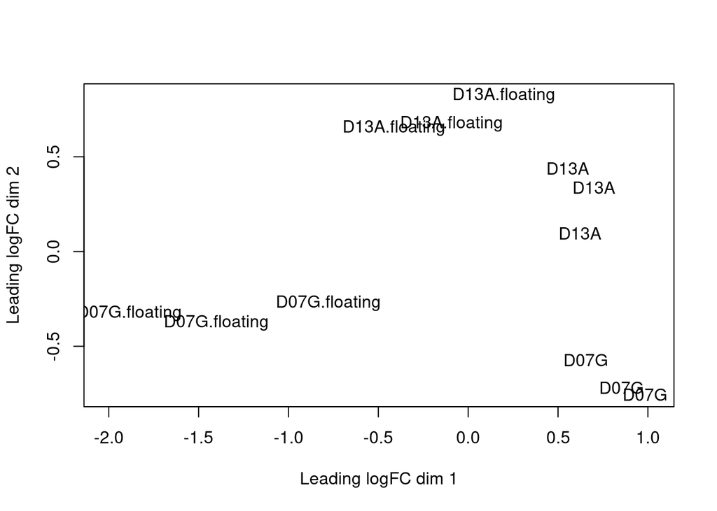

```r
mds = plotMDS(ob, labels = ob$samples$group, top=5000)
```

## Filtering

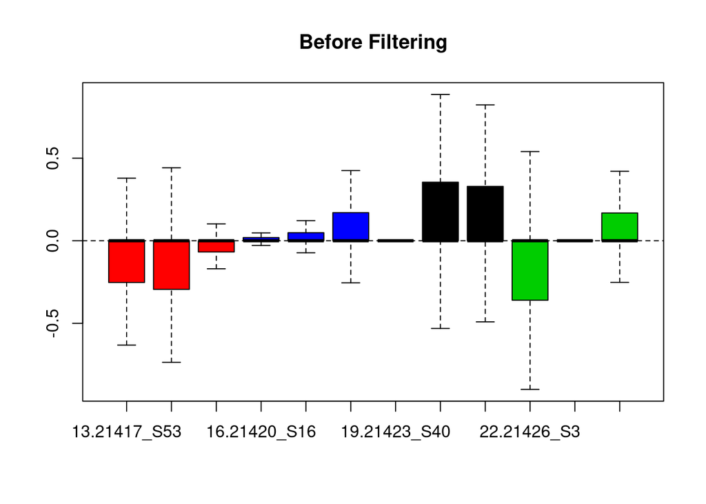

```r
plotRLE(ob$counts, outline=FALSE, col=ob$samples$group, main="Before Filtering")
```

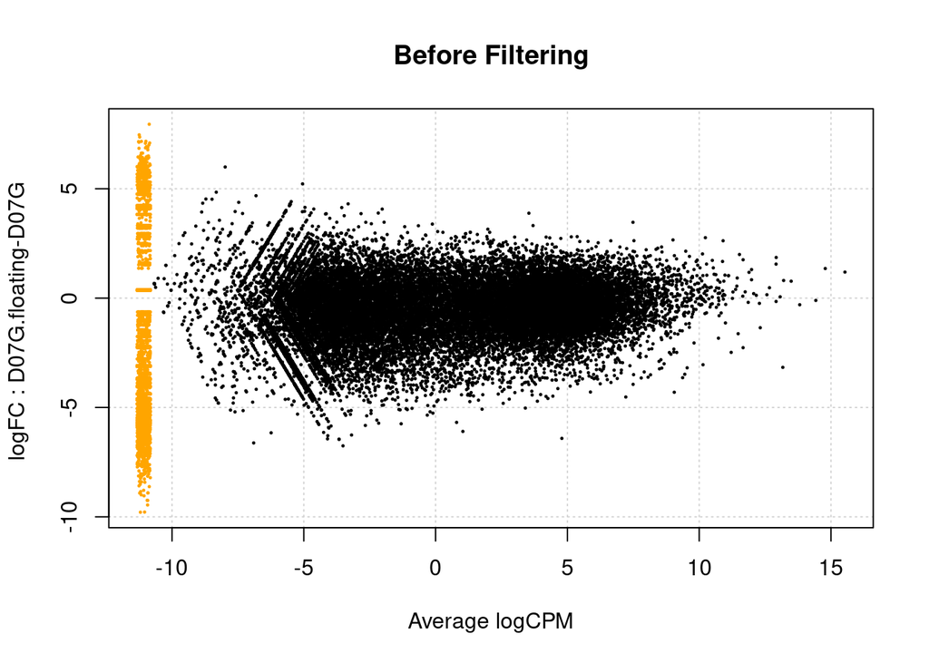

```r
plotSmear(ob, main = "Before Filtering")
```

```r
nrow(ob) #58 735 genes before filtering
```

```
## [1] 58735
```

```r
filt = ob[filterByExpr(ob),, keep.lib.sizes=FALSE]
nrow(filt) #17 882 genes kept after filtering
```

```
## [1] 17882
```

The exact filter is approxiamtely 10/ libsize in millions (now about 0.2 CPM). This is a lower filter than previous, I guess because our library sizes are bigger.

```r
10/(median(ob$samples$lib.size)/1000000) #0.190 minimum CPM
```

```
## [1] 0.1901267
```

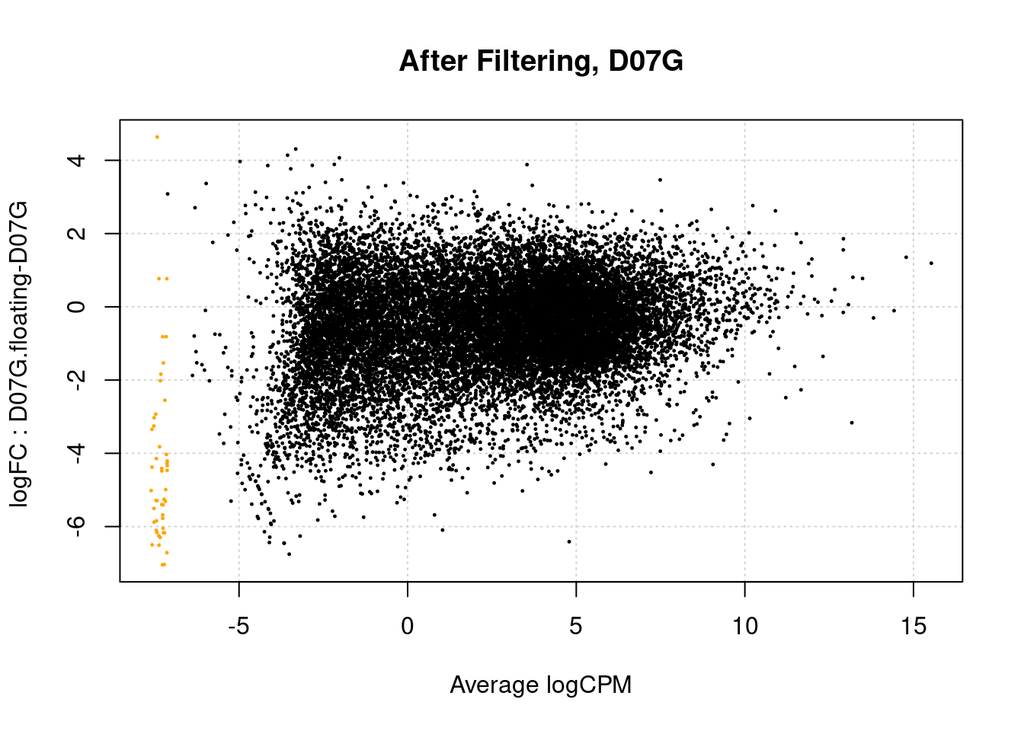

```r
plotSmear(filt, main = "After Filtering, D07G")
```

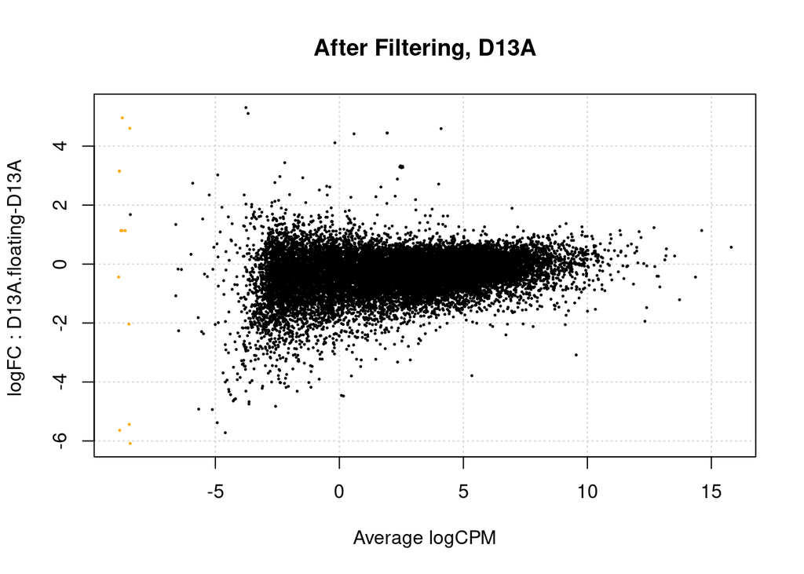

```r
plotSmear(filt, main = "After Filtering, D13A", pair=c("D13A","D13A.floating"))
```

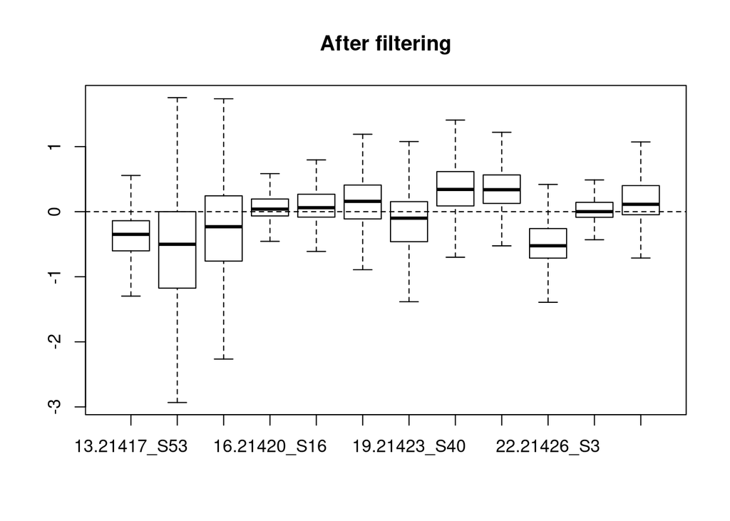

```r
plotRLE(filt$counts, outline=FALSE,
        col=filt$samples$treat, main="After filtering")
```

Sanity check that the geneids haven’t been mixed up.

```r
filt$genes[filt$genes$Geneid == "ENSG00000228630",] #Hotair is still included
```

```
##                Geneid Length
## 37431 ENSG00000228630   2602
```

```r
filt$genes[filt$genes$Geneid == "ENSG00000132170",] #PPARG is included
```

```
##               Geneid Length
## 9485 ENSG00000132170   4535
```

## Normalise

Hmm these libraries have quite a bit of substructure, the means are not around zero, and the variances have quite large differences, particularly for two of those donor7 floating samples. You can see they sit differently in the PCA.

```r
filt = calcNormFactors(filt,method = "TMM")
filt$samples[1:5]
```

```
##                      group lib.size norm.factors time  rep
## 13.21417_S53 D07G.floating 39508175    0.9340652  D15   P6
## 14.21418_S2  D07G.floating 43186506    0.7584613  D15 P8_1
## 15.21419_S9  D07G.floating 53177563    0.7813403  D15 P8_2
## 16.21420_S16 D13A.floating 58737144    0.9856742  D15 P6_1
## 17.21421_S24 D13A.floating 64198765    0.9363287  D15 P6_2
## 18.21422_S32 D13A.floating 65275068    0.9953401  D15   P7
## 19.21423_S40          D07G 43492838    1.1040517  D15   P7
## 20.21424_S47          D07G 68497143    1.1196543  D15 P8_2
## 21.21425_S54          D07G 67310638    1.1531789  D15 P8_1
## 22.21426_S3           D13A 28511179    1.1061111  D15   P7
## 23.21427_S10          D13A 51385275    1.0600427  D15   P6
## 24.21428_S17          D13A 51968129    1.1765865  D15   P7
```

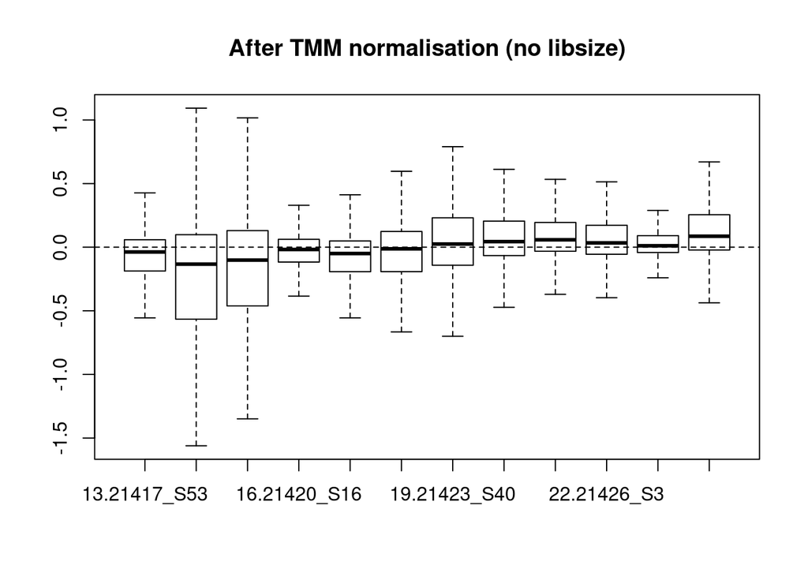

```r
plotRLE(cpm(filt$counts, normalized.lib.sizes =FALSE), outline=FALSE,
             main="After TMM normalisation (no libsize)")
```

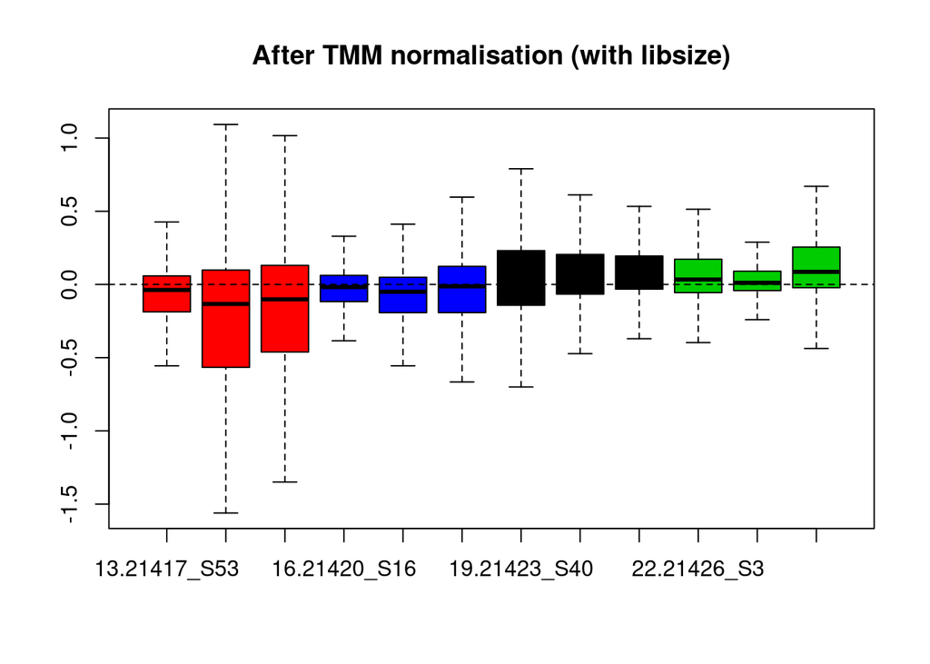

```r
plotRLE(cpm(filt$counts, normalized.lib.sizes = TRUE), outline=FALSE,
        col=filt$samples$group, main="After TMM normalisation (with libsize)")
```